# R Notebook

# c) bmi and epworth score :

# This scatterplot helps us to determine whether the bmi and epworth score are corelated to each other or not, it shows that the two attributes are not corelated and has no proportional relationship.

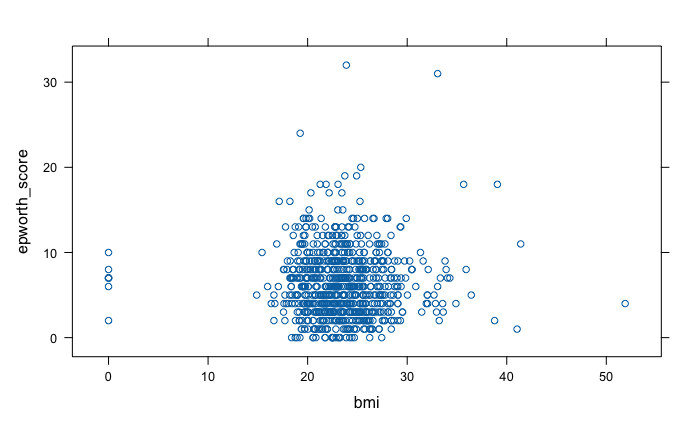

```r
xyplot(epworth_score~bmi,data = dataset)
```

##the total null values in the dataset is 41

```r
is.na(dataset)
```

[output not shown]

[output cut: 145 more lines]

```r
sum(is.na(dataset))
```

```
[1] 41
```

###Detect Outlier

```r
install.packages("outliers")
```

```
Error in install.packages : Updating loaded packages
```

```r
library(outliers)

Outage = outlier(dataset$age, logical =TRUE)
sum(Outage)
```

```
[1] 1
```

```r
Find_outlier = which(Outage ==TRUE, arr.ind = TRUE)
Outage
```

```
  [1] FALSE FALSE FALSE FALSE FALSE FALSE FALSE FALSE FALSE FALSE FALSE FALSE FALSE FALSE FALSE FALSE FALSE FALSE FALSE
 [20] FALSE FALSE FALSE FALSE FALSE FALSE FALSE FALSE FALSE FALSE FALSE FALSE FALSE FALSE FALSE FALSE FALSE FALSE FALSE
 [39] FALSE FALSE FALSE FALSE FALSE FALSE FALSE FALSE FALSE FALSE FALSE FALSE FALSE FALSE FALSE FALSE FALSE FALSE FALSE
 [58] FALSE FALSE FALSE FALSE FALSE FALSE FALSE FALSE FALSE FALSE FALSE FALSE FALSE FALSE FALSE FALSE FALSE FALSE FALSE
 [77] FALSE FALSE FALSE FALSE FALSE FALSE FALSE FALSE FALSE FALSE FALSE FALSE FALSE FALSE FALSE FALSE FALSE FALSE FALSE
 [96] FALSE FALSE FALSE FALSE FALSE FALSE FALSE FALSE FALSE FALSE FALSE FALSE FALSE FALSE FALSE FALSE FALSE FALSE FALSE
[115] FALSE FALSE FALSE FALSE FALSE FALSE FALSE FALSE FALSE FALSE FALSE FALSE FALSE FALSE FALSE FALSE FALSE FALSE FALSE
[134] FALSE FALSE FALSE FALSE FALSE FALSE FALSE FALSE FALSE FALSE FALSE FALSE FALSE FALSE FALSE FALSE FALSE FALSE FALSE
[153] FALSE FALSE FALSE FALSE FALSE FALSE FALSE FALSE FALSE FALSE FALSE FALSE FALSE FALSE FALSE FALSE FALSE FALSE FALSE
[172] FALSE FALSE FALSE FALSE FALSE FALSE FALSE FALSE FALSE FALSE FALSE FALSE FALSE FALSE FALSE FALSE FALSE FALSE FALSE
[191] FALSE FALSE FALSE FALSE FALSE FALSE FALSE FALSE FALSE FALSE FALSE FALSE FALSE FALSE FALSE FALSE FALSE FALSE FALSE
[210] FALSE FALSE FALSE FALSE FALSE FALSE FALSE FALSE FALSE FALSE FALSE FALSE FALSE FALSE FALSE FALSE FALSE FALSE FALSE
[229] FALSE FALSE FALSE FALSE FALSE FALSE FALSE FALSE FALSE FALSE FALSE FALSE FALSE FALSE FALSE FALSE FALSE FALSE FALSE
[248] FALSE FALSE FALSE FALSE FALSE FALSE FALSE FALSE FALSE FALSE FALSE FALSE FALSE FALSE FALSE FALSE FALSE FALSE FALSE
[267] FALSE FALSE FALSE FALSE FALSE FALSE FALSE FALSE FALSE FALSE FALSE FALSE FALSE FALSE FALSE FALSE FALSE FALSE FALSE
```

[output cut: 27 more lines]

```r
Find_outlier
```

```
[1] 740
```

```r
Outbmi= outlier(dataset$bmi, logical =TRUE)
sum(Outbmi)
```

```
[1] 1
```

```r
Find_outlier2 = which(Outbmi==TRUE, arr.ind = TRUE)
Outbmi
```

```
  [1] FALSE FALSE FALSE FALSE FALSE FALSE FALSE FALSE FALSE FALSE FALSE FALSE FALSE FALSE FALSE FALSE FALSE FALSE FALSE
 [20] FALSE FALSE FALSE FALSE FALSE FALSE FALSE FALSE FALSE FALSE FALSE FALSE FALSE FALSE FALSE FALSE FALSE FALSE FALSE
 [39] FALSE FALSE FALSE FALSE FALSE FALSE FALSE FALSE FALSE FALSE FALSE FALSE FALSE FALSE FALSE FALSE FALSE FALSE FALSE
 [58] FALSE FALSE FALSE FALSE FALSE FALSE FALSE FALSE FALSE FALSE  TRUE FALSE FALSE FALSE FALSE FALSE FALSE FALSE FALSE
 [77] FALSE FALSE FALSE FALSE FALSE FALSE FALSE FALSE FALSE FALSE FALSE FALSE FALSE FALSE FALSE FALSE FALSE FALSE FALSE
 [96] FALSE FALSE FALSE FALSE FALSE FALSE FALSE FALSE FALSE FALSE FALSE FALSE FALSE FALSE FALSE FALSE FALSE FALSE FALSE
[115] FALSE FALSE FALSE FALSE FALSE FALSE FALSE FALSE FALSE FALSE FALSE FALSE FALSE FALSE FALSE FALSE FALSE FALSE FALSE
[134] FALSE FALSE FALSE FALSE FALSE FALSE FALSE FALSE FALSE FALSE FALSE FALSE FALSE FALSE FALSE FALSE FALSE FALSE FALSE
[153] FALSE FALSE FALSE FALSE FALSE FALSE FALSE FALSE FALSE FALSE FALSE FALSE FALSE FALSE FALSE FALSE FALSE FALSE FALSE
[172] FALSE FALSE FALSE FALSE FALSE FALSE FALSE FALSE FALSE FALSE FALSE FALSE FALSE FALSE FALSE FALSE FALSE FALSE FALSE
[191] FALSE FALSE FALSE FALSE FALSE FALSE FALSE FALSE FALSE FALSE FALSE FALSE FALSE FALSE FALSE FALSE FALSE FALSE FALSE
[210] FALSE FALSE FALSE FALSE FALSE FALSE FALSE FALSE FALSE FALSE FALSE FALSE FALSE FALSE FALSE FALSE FALSE FALSE FALSE
[229] FALSE FALSE FALSE FALSE FALSE FALSE FALSE FALSE FALSE FALSE FALSE FALSE FALSE FALSE FALSE FALSE FALSE FALSE FALSE
[248] FALSE FALSE FALSE FALSE FALSE FALSE FALSE FALSE FALSE FALSE FALSE FALSE FALSE FALSE FALSE FALSE FALSE FALSE FALSE
[267] FALSE FALSE FALSE FALSE FALSE FALSE FALSE FALSE FALSE FALSE FALSE FALSE FALSE FALSE FALSE FALSE FALSE FALSE FALSE
```

[output cut: 27 more lines]

```r
Find_outlier2
```

```
[1] 68
```

#delet outlier

```r
dataset= dataset[-Find_outlier,]
dataset= dataset[-Find_outlier2,]
```

##Data Trasformation (Encoding the binary data type to 0,1)

```r
dataset$depressiveness = factor (dataset$depressiveness, levels = c(TRUE,FALSE), labels=c(1,0))
print(dataset)
```

|  | id | school_year | age | gender | bmi | who_bmi | phq_score | depression_severity | depressiveness | suicidal | depression_diagnosis | depression_treatment | gad_score | anxiety_severity | anxiousness | anxiety_diagnosis | anxiety_treatment | epworth_score | sleepiness |
| --- | --- | --- | --- | --- | --- | --- | --- | --- | --- | --- | --- | --- | --- | --- | --- | --- | --- | --- | --- |
| 1 | 1 | 1 | 19 | male | 33.33333 | Class I Obesity | 9 | Mild | 0 | FALSE | FALSE | FALSE | 11 | Moderate | TRUE | FALSE | FALSE | 7 | FALSE |
| 2 | 2 | 1 | 18 | male | 19.84127 | Normal | 8 | Mild | 0 | FALSE | FALSE | FALSE | 5 | Mild | FALSE | FALSE | FALSE | 14 | TRUE |
| 3 | 3 | 1 | 19 | male | 25.10239 | Overweight | 8 | Mild | 0 | FALSE | FALSE | FALSE | 6 | Mild | FALSE | FALSE | FALSE | 6 | FALSE |
| 4 | 4 | 1 | 18 | female | 23.73866 | Normal | 19 | Moderately severe | 1 | TRUE | FALSE | FALSE | 15 | Severe | TRUE | FALSE | FALSE | 11 | TRUE |
| 5 | 5 | 1 | 18 | male | 25.61728 | Overweight | 6 | Mild | 0 | FALSE | FALSE | FALSE | 14 | Moderate | TRUE | FALSE | FALSE | 3 | FALSE |
| 6 | 6 | 1 | 18 | male | 22.12974 | Normal | 3 | None-minimal | 0 | FALSE | FALSE | FALSE | 2 | None-minimal | FALSE | FALSE | FALSE | 2 | FALSE |
| 7 | 7 | 1 | 18 | male | 22.40879 | Normal | 6 | Mild | 0 | FALSE | FALSE | FALSE | 4 | None-minimal | FALSE | FALSE | FALSE | 3 | FALSE |
| 8 | 8 | 1 | 19 | male | 20.48248 | Normal | 4 | None-minimal | 0 | FALSE | FALSE | FALSE | 9 | Mild | FALSE | FALSE | FALSE | 5 | FALSE |
| 9 | 9 | 1 | 20 | male | 21.22789 | Normal | 11 | Moderate | 1 | FALSE | FALSE | FALSE | 8 | Mild | FALSE | FALSE | FALSE | 7 | FALSE |
| 10 | 10 | 1 | 19 | male | 24.48980 | Normal | 6 | Mild | 0 | FALSE | FALSE | FALSE | 4 | None-minimal | FALSE | FALSE | FALSE | 9 | FALSE |

[output cut: 768 more lines]

```r
dataset$suicidal = factor (dataset$suicidal, levels = c(TRUE,FALSE), labels=c(1,0))
print(dataset)
```

|  | id | school_year | age | gender | bmi | who_bmi | phq_score | depression_severity | depressiveness | suicidal | depression_diagnosis | depression_treatment | gad_score | anxiety_severity | anxiousness | anxiety_diagnosis | anxiety_treatment | epworth_score | sleepiness |
| --- | --- | --- | --- | --- | --- | --- | --- | --- | --- | --- | --- | --- | --- | --- | --- | --- | --- | --- | --- |
| 1 | 1 | 1 | 19 | male | 33.33333 | Class I Obesity | 9 | Mild | 0 | 0 | FALSE | FALSE | 11 | Moderate | TRUE | FALSE | FALSE | 7 | FALSE |
| 2 | 2 | 1 | 18 | male | 19.84127 | Normal | 8 | Mild | 0 | 0 | FALSE | FALSE | 5 | Mild | FALSE | FALSE | FALSE | 14 | TRUE |
| 3 | 3 | 1 | 19 | male | 25.10239 | Overweight | 8 | Mild | 0 | 0 | FALSE | FALSE | 6 | Mild | FALSE | FALSE | FALSE | 6 | FALSE |
| 4 | 4 | 1 | 18 | female | 23.73866 | Normal | 19 | Moderately severe | 1 | 1 | FALSE | FALSE | 15 | Severe | TRUE | FALSE | FALSE | 11 | TRUE |
| 5 | 5 | 1 | 18 | male | 25.61728 | Overweight | 6 | Mild | 0 | 0 | FALSE | FALSE | 14 | Moderate | TRUE | FALSE | FALSE | 3 | FALSE |
| 6 | 6 | 1 | 18 | male | 22.12974 | Normal | 3 | None-minimal | 0 | 0 | FALSE | FALSE | 2 | None-minimal | FALSE | FALSE | FALSE | 2 | FALSE |
| 7 | 7 | 1 | 18 | male | 22.40879 | Normal | 6 | Mild | 0 | 0 | FALSE | FALSE | 4 | None-minimal | FALSE | FALSE | FALSE | 3 | FALSE |
| 8 | 8 | 1 | 19 | male | 20.48248 | Normal | 4 | None-minimal | 0 | 0 | FALSE | FALSE | 9 | Mild | FALSE | FALSE | FALSE | 5 | FALSE |
| 9 | 9 | 1 | 20 | male | 21.22789 | Normal | 11 | Moderate | 1 | 0 | FALSE | FALSE | 8 | Mild | FALSE | FALSE | FALSE | 7 | FALSE |
| 10 | 10 | 1 | 19 | male | 24.48980 | Normal | 6 | Mild | 0 | 0 | FALSE | FALSE | 4 | None-minimal | FALSE | FALSE | FALSE | 9 | FALSE |

[output cut: 768 more lines]

```r
dataset$depression_diagnosis = factor (dataset$depression_diagnosis, levels = c(TRUE,FALSE), labels=c(1,0))
print(dataset)
```

|  | id | school_year | age | gender | bmi | who_bmi | phq_score | depression_severity | depressiveness | suicidal | depression_diagnosis | depression_treatment | gad_score | anxiety_severity | anxiousness | anxiety_diagnosis | anxiety_treatment | epworth_score | sleepiness |
| --- | --- | --- | --- | --- | --- | --- | --- | --- | --- | --- | --- | --- | --- | --- | --- | --- | --- | --- | --- |
| 1 | 1 | 1 | 19 | male | 33.33333 | Class I Obesity | 9 | Mild | 0 | 0 | 0 | FALSE | 11 | Moderate | TRUE | FALSE | FALSE | 7 | FALSE |
| 2 | 2 | 1 | 18 | male | 19.84127 | Normal | 8 | Mild | 0 | 0 | 0 | FALSE | 5 | Mild | FALSE | FALSE | FALSE | 14 | TRUE |
| 3 | 3 | 1 | 19 | male | 25.10239 | Overweight | 8 | Mild | 0 | 0 | 0 | FALSE | 6 | Mild | FALSE | FALSE | FALSE | 6 | FALSE |
| 4 | 4 | 1 | 18 | female | 23.73866 | Normal | 19 | Moderately severe | 1 | 1 | 0 | FALSE | 15 | Severe | TRUE | FALSE | FALSE | 11 | TRUE |
| 5 | 5 | 1 | 18 | male | 25.61728 | Overweight | 6 | Mild | 0 | 0 | 0 | FALSE | 14 | Moderate | TRUE | FALSE | FALSE | 3 | FALSE |
| 6 | 6 | 1 | 18 | male | 22.12974 | Normal | 3 | None-minimal | 0 | 0 | 0 | FALSE | 2 | None-minimal | FALSE | FALSE | FALSE | 2 | FALSE |
| 7 | 7 | 1 | 18 | male | 22.40879 | Normal | 6 | Mild | 0 | 0 | 0 | FALSE | 4 | None-minimal | FALSE | FALSE | FALSE | 3 | FALSE |
| 8 | 8 | 1 | 19 | male | 20.48248 | Normal | 4 | None-minimal | 0 | 0 | 0 | FALSE | 9 | Mild | FALSE | FALSE | FALSE | 5 | FALSE |
| 9 | 9 | 1 | 20 | male | 21.22789 | Normal | 11 | Moderate | 1 | 0 | 0 | FALSE | 8 | Mild | FALSE | FALSE | FALSE | 7 | FALSE |
| 10 | 10 | 1 | 19 | male | 24.48980 | Normal | 6 | Mild | 0 | 0 | 0 | FALSE | 4 | None-minimal | FALSE | FALSE | FALSE | 9 | FALSE |

[output cut: 768 more lines]

```r
dataset$depression_treatment = factor (dataset$depression_treatment, levels = c(TRUE,FALSE), labels=c(1,0))
print(dataset)
```

|  | id | school_year | age | gender | bmi | who_bmi | phq_score | depression_severity | depressiveness | suicidal | depression_diagnosis | depression_treatment | gad_score | anxiety_severity | anxiousness | anxiety_diagnosis | anxiety_treatment | epworth_score | sleepiness |
| --- | --- | --- | --- | --- | --- | --- | --- | --- | --- | --- | --- | --- | --- | --- | --- | --- | --- | --- | --- |
| 1 | 1 | 1 | 19 | male | 33.33333 | Class I Obesity | 9 | Mild | 0 | 0 | 0 | 0 | 11 | Moderate | TRUE | FALSE | FALSE | 7 | FALSE |
| 2 | 2 | 1 | 18 | male | 19.84127 | Normal | 8 | Mild | 0 | 0 | 0 | 0 | 5 | Mild | FALSE | FALSE | FALSE | 14 | TRUE |
| 3 | 3 | 1 | 19 | male | 25.10239 | Overweight | 8 | Mild | 0 | 0 | 0 | 0 | 6 | Mild | FALSE | FALSE | FALSE | 6 | FALSE |
| 4 | 4 | 1 | 18 | female | 23.73866 | Normal | 19 | Moderately severe | 1 | 1 | 0 | 0 | 15 | Severe | TRUE | FALSE | FALSE | 11 | TRUE |
| 5 | 5 | 1 | 18 | male | 25.61728 | Overweight | 6 | Mild | 0 | 0 | 0 | 0 | 14 | Moderate | TRUE | FALSE | FALSE | 3 | FALSE |
| 6 | 6 | 1 | 18 | male | 22.12974 | Normal | 3 | None-minimal | 0 | 0 | 0 | 0 | 2 | None-minimal | FALSE | FALSE | FALSE | 2 | FALSE |
| 7 | 7 | 1 | 18 | male | 22.40879 | Normal | 6 | Mild | 0 | 0 | 0 | 0 | 4 | None-minimal | FALSE | FALSE | FALSE | 3 | FALSE |
| 8 | 8 | 1 | 19 | male | 20.48248 | Normal | 4 | None-minimal | 0 | 0 | 0 | 0 | 9 | Mild | FALSE | FALSE | FALSE | 5 | FALSE |
| 9 | 9 | 1 | 20 | male | 21.22789 | Normal | 11 | Moderate | 1 | 0 | 0 | 0 | 8 | Mild | FALSE | FALSE | FALSE | 7 | FALSE |
| 10 | 10 | 1 | 19 | male | 24.48980 | Normal | 6 | Mild | 0 | 0 | 0 | 0 | 4 | None-minimal | FALSE | FALSE | FALSE | 9 | FALSE |

[output cut: 768 more lines]

```r
dataset$anxiousness = factor (dataset$anxiousness, levels = c(TRUE,FALSE), labels=c(1,0))
print(dataset)
```

|  | id | school_year | age | gender | bmi | who_bmi | phq_score | depression_severity | depressiveness | suicidal | depression_diagnosis | depression_treatment | gad_score | anxiety_severity | anxiousness | anxiety_diagnosis | anxiety_treatment | epworth_score | sleepiness |
| --- | --- | --- | --- | --- | --- | --- | --- | --- | --- | --- | --- | --- | --- | --- | --- | --- | --- | --- | --- |
| 1 | 1 | 1 | 19 | male | 33.33333 | Class I Obesity | 9 | Mild | 0 | 0 | 0 | 0 | 11 | Moderate | 1 | FALSE | FALSE | 7 | FALSE |
| 2 | 2 | 1 | 18 | male | 19.84127 | Normal | 8 | Mild | 0 | 0 | 0 | 0 | 5 | Mild | 0 | FALSE | FALSE | 14 | TRUE |
| 3 | 3 | 1 | 19 | male | 25.10239 | Overweight | 8 | Mild | 0 | 0 | 0 | 0 | 6 | Mild | 0 | FALSE | FALSE | 6 | FALSE |
| 4 | 4 | 1 | 18 | female | 23.73866 | Normal | 19 | Moderately severe | 1 | 1 | 0 | 0 | 15 | Severe | 1 | FALSE | FALSE | 11 | TRUE |
| 5 | 5 | 1 | 18 | male | 25.61728 | Overweight | 6 | Mild | 0 | 0 | 0 | 0 | 14 | Moderate | 1 | FALSE | FALSE | 3 | FALSE |
| 6 | 6 | 1 | 18 | male | 22.12974 | Normal | 3 | None-minimal | 0 | 0 | 0 | 0 | 2 | None-minimal | 0 | FALSE | FALSE | 2 | FALSE |
| 7 | 7 | 1 | 18 | male | 22.40879 | Normal | 6 | Mild | 0 | 0 | 0 | 0 | 4 | None-minimal | 0 | FALSE | FALSE | 3 | FALSE |
| 8 | 8 | 1 | 19 | male | 20.48248 | Normal | 4 | None-minimal | 0 | 0 | 0 | 0 | 9 | Mild | 0 | FALSE | FALSE | 5 | FALSE |
| 9 | 9 | 1 | 20 | male | 21.22789 | Normal | 11 | Moderate | 1 | 0 | 0 | 0 | 8 | Mild | 0 | FALSE | FALSE | 7 | FALSE |
| 10 | 10 | 1 | 19 | male | 24.48980 | Normal | 6 | Mild | 0 | 0 | 0 | 0 | 4 | None-minimal | 0 | FALSE | FALSE | 9 | FALSE |

[output cut: 768 more lines]

```r
dataset$anxiety_diagnosis = factor (dataset$anxiety_diagnosis, levels = c(TRUE,FALSE), labels=c(1,0))
print(dataset)
```

|  | id | school_year | age | gender | bmi | who_bmi | phq_score | depression_severity | depressiveness | suicidal | depression_diagnosis | depression_treatment | gad_score | anxiety_severity | anxiousness | anxiety_diagnosis | anxiety_treatment | epworth_score | sleepiness |
| --- | --- | --- | --- | --- | --- | --- | --- | --- | --- | --- | --- | --- | --- | --- | --- | --- | --- | --- | --- |
| 1 | 1 | 1 | 19 | male | 33.33333 | Class I Obesity | 9 | Mild | 0 | 0 | 0 | 0 | 11 | Moderate | 1 | 0 | FALSE | 7 | FALSE |
| 2 | 2 | 1 | 18 | male | 19.84127 | Normal | 8 | Mild | 0 | 0 | 0 | 0 | 5 | Mild | 0 | 0 | FALSE | 14 | TRUE |
| 3 | 3 | 1 | 19 | male | 25.10239 | Overweight | 8 | Mild | 0 | 0 | 0 | 0 | 6 | Mild | 0 | 0 | FALSE | 6 | FALSE |
| 4 | 4 | 1 | 18 | female | 23.73866 | Normal | 19 | Moderately severe | 1 | 1 | 0 | 0 | 15 | Severe | 1 | 0 | FALSE | 11 | TRUE |
| 5 | 5 | 1 | 18 | male | 25.61728 | Overweight | 6 | Mild | 0 | 0 | 0 | 0 | 14 | Moderate | 1 | 0 | FALSE | 3 | FALSE |
| 6 | 6 | 1 | 18 | male | 22.12974 | Normal | 3 | None-minimal | 0 | 0 | 0 | 0 | 2 | None-minimal | 0 | 0 | FALSE | 2 | FALSE |
| 7 | 7 | 1 | 18 | male | 22.40879 | Normal | 6 | Mild | 0 | 0 | 0 | 0 | 4 | None-minimal | 0 | 0 | FALSE | 3 | FALSE |
| 8 | 8 | 1 | 19 | male | 20.48248 | Normal | 4 | None-minimal | 0 | 0 | 0 | 0 | 9 | Mild | 0 | 0 | FALSE | 5 | FALSE |
| 9 | 9 | 1 | 20 | male | 21.22789 | Normal | 11 | Moderate | 1 | 0 | 0 | 0 | 8 | Mild | 0 | 0 | FALSE | 7 | FALSE |
| 10 | 10 | 1 | 19 | male | 24.48980 | Normal | 6 | Mild | 0 | 0 | 0 | 0 | 4 | None-minimal | 0 | 0 | FALSE | 9 | FALSE |

[output cut: 768 more lines]

```r
dataset$anxiety_treatment = factor (dataset$anxiety_treatment, levels = c(TRUE,FALSE), labels=c(1,0))
print(dataset)
```

|  | id | school_year | age | gender | bmi | who_bmi | phq_score | depression_severity | depressiveness | suicidal | depression_diagnosis | depression_treatment | gad_score | anxiety_severity | anxiousness | anxiety_diagnosis | anxiety_treatment | epworth_score | sleepiness |
| --- | --- | --- | --- | --- | --- | --- | --- | --- | --- | --- | --- | --- | --- | --- | --- | --- | --- | --- | --- |
| 1 | 1 | 1 | 19 | male | 33.33333 | Class I Obesity | 9 | Mild | 0 | 0 | 0 | 0 | 11 | Moderate | 1 | 0 | 0 | 7 | FALSE |
| 2 | 2 | 1 | 18 | male | 19.84127 | Normal | 8 | Mild | 0 | 0 | 0 | 0 | 5 | Mild | 0 | 0 | 0 | 14 | TRUE |
| 3 | 3 | 1 | 19 | male | 25.10239 | Overweight | 8 | Mild | 0 | 0 | 0 | 0 | 6 | Mild | 0 | 0 | 0 | 6 | FALSE |
| 4 | 4 | 1 | 18 | female | 23.73866 | Normal | 19 | Moderately severe | 1 | 1 | 0 | 0 | 15 | Severe | 1 | 0 | 0 | 11 | TRUE |
| 5 | 5 | 1 | 18 | male | 25.61728 | Overweight | 6 | Mild | 0 | 0 | 0 | 0 | 14 | Moderate | 1 | 0 | 0 | 3 | FALSE |
| 6 | 6 | 1 | 18 | male | 22.12974 | Normal | 3 | None-minimal | 0 | 0 | 0 | 0 | 2 | None-minimal | 0 | 0 | 0 | 2 | FALSE |
| 7 | 7 | 1 | 18 | male | 22.40879 | Normal | 6 | Mild | 0 | 0 | 0 | 0 | 4 | None-minimal | 0 | 0 | 0 | 3 | FALSE |
| 8 | 8 | 1 | 19 | male | 20.48248 | Normal | 4 | None-minimal | 0 | 0 | 0 | 0 | 9 | Mild | 0 | 0 | 0 | 5 | FALSE |
| 9 | 9 | 1 | 20 | male | 21.22789 | Normal | 11 | Moderate | 1 | 0 | 0 | 0 | 8 | Mild | 0 | 0 | 0 | 7 | FALSE |
| 10 | 10 | 1 | 19 | male | 24.48980 | Normal | 6 | Mild | 0 | 0 | 0 | 0 | 4 | None-minimal | 0 | 0 | 0 | 9 | FALSE |

[output cut: 768 more lines]

```r
dataset$sleepiness = factor (dataset$sleepiness, levels = c(TRUE,FALSE), labels=c(1,0))
print(dataset)
```

|  | id | school_year | age | gender | bmi | who_bmi | phq_score | depression_severity | depressiveness | suicidal | depression_diagnosis | depression_treatment | gad_score | anxiety_severity | anxiousness | anxiety_diagnosis | anxiety_treatment | epworth_score | sleepiness |
| --- | --- | --- | --- | --- | --- | --- | --- | --- | --- | --- | --- | --- | --- | --- | --- | --- | --- | --- | --- |
| 1 | 1 | 1 | 19 | male | 33.33333 | Class I Obesity | 9 | Mild | 0 | 0 | 0 | 0 | 11 | Moderate | 1 | 0 | 0 | 7 | 0 |
| 2 | 2 | 1 | 18 | male | 19.84127 | Normal | 8 | Mild | 0 | 0 | 0 | 0 | 5 | Mild | 0 | 0 | 0 | 14 | 1 |
| 3 | 3 | 1 | 19 | male | 25.10239 | Overweight | 8 | Mild | 0 | 0 | 0 | 0 | 6 | Mild | 0 | 0 | 0 | 6 | 0 |
| 4 | 4 | 1 | 18 | female | 23.73866 | Normal | 19 | Moderately severe | 1 | 1 | 0 | 0 | 15 | Severe | 1 | 0 | 0 | 11 | 1 |
| 5 | 5 | 1 | 18 | male | 25.61728 | Overweight | 6 | Mild | 0 | 0 | 0 | 0 | 14 | Moderate | 1 | 0 | 0 | 3 | 0 |
| 6 | 6 | 1 | 18 | male | 22.12974 | Normal | 3 | None-minimal | 0 | 0 | 0 | 0 | 2 | None-minimal | 0 | 0 | 0 | 2 | 0 |
| 7 | 7 | 1 | 18 | male | 22.40879 | Normal | 6 | Mild | 0 | 0 | 0 | 0 | 4 | None-minimal | 0 | 0 | 0 | 3 | 0 |
| 8 | 8 | 1 | 19 | male | 20.48248 | Normal | 4 | None-minimal | 0 | 0 | 0 | 0 | 9 | Mild | 0 | 0 | 0 | 5 | 0 |
| 9 | 9 | 1 | 20 | male | 21.22789 | Normal | 11 | Moderate | 1 | 0 | 0 | 0 | 8 | Mild | 0 | 0 | 0 | 7 | 0 |
| 10 | 10 | 1 | 19 | male | 24.48980 | Normal | 6 | Mild | 0 | 0 | 0 | 0 | 4 | None-minimal | 0 | 0 | 0 | 9 | 0 |

[output cut: 768 more lines]

```r
NA
NA
```

### Data Transformation (Discretization the values based on fixed set of predetermined criteria)

#1- bmi discretizatio (indicate high body fatness)

```r
breaks <- c(18,18.4,24.9,29.9,34.9,39.9,100)
dataset$bmi= cut(dataset$bmi, breaks = breaks)
print(dataset)
```

|  | id | school_year | age | gender | bmi | who_bmi | phq_score | depression_severity | depressiveness | suicidal | depression_diagnosis | depression_treatment | gad_score | anxiety_severity | anxiousness | anxiety_diagnosis | anxiety_treatment | epworth_score | sleepiness |
| --- | --- | --- | --- | --- | --- | --- | --- | --- | --- | --- | --- | --- | --- | --- | --- | --- | --- | --- | --- |
| 1 | 1 | 1 | 19 | male | (29.9,34.9] | Class I Obesity | 9 | Mild | 0 | 0 | 0 | 0 | 11 | Moderate | 1 | 0 | 0 | 7 | 0 |
| 2 | 2 | 1 | 18 | male | (18.4,24.9] | Normal | 8 | Mild | 0 | 0 | 0 | 0 | 5 | Mild | 0 | 0 | 0 | 14 | 1 |
| 3 | 3 | 1 | 19 | male | (24.9,29.9] | Overweight | 8 | Mild | 0 | 0 | 0 | 0 | 6 | Mild | 0 | 0 | 0 | 6 | 0 |
| 4 | 4 | 1 | 18 | female | (18.4,24.9] | Normal | 19 | Moderately severe | 1 | 1 | 0 | 0 | 15 | Severe | 1 | 0 | 0 | 11 | 1 |
| 5 | 5 | 1 | 18 | male | (24.9,29.9] | Overweight | 6 | Mild | 0 | 0 | 0 | 0 | 14 | Moderate | 1 | 0 | 0 | 3 | 0 |
| 6 | 6 | 1 | 18 | male | (18.4,24.9] | Normal | 3 | None-minimal | 0 | 0 | 0 | 0 | 2 | None-minimal | 0 | 0 | 0 | 2 | 0 |
| 7 | 7 | 1 | 18 | male | (18.4,24.9] | Normal | 6 | Mild | 0 | 0 | 0 | 0 | 4 | None-minimal | 0 | 0 | 0 | 3 | 0 |
| 8 | 8 | 1 | 19 | male | (18.4,24.9] | Normal | 4 | None-minimal | 0 | 0 | 0 | 0 | 9 | Mild | 0 | 0 | 0 | 5 | 0 |
| 9 | 9 | 1 | 20 | male | (18.4,24.9] | Normal | 11 | Moderate | 1 | 0 | 0 | 0 | 8 | Mild | 0 | 0 | 0 | 7 | 0 |
| 10 | 10 | 1 | 19 | male | (18.4,24.9] | Normal | 6 | Mild | 0 | 0 | 0 | 0 | 4 | None-minimal | 0 | 0 | 0 | 9 | 0 |

[output cut: 768 more lines]

#2- phq test score discretizatio(Depression Test Questionnaire)

```r
breaks <- c(0,4,9,14,19,27)
dataset$phq_score= cut(dataset$phq_score, breaks = breaks)
print(dataset)
```

|  | id | school_year | age | gender | bmi | who_bmi | phq_score | depression_severity | depressiveness | suicidal | depression_diagnosis | depression_treatment | gad_score | anxiety_severity | anxiousness | anxiety_diagnosis | anxiety_treatment | epworth_score | sleepiness |
| --- | --- | --- | --- | --- | --- | --- | --- | --- | --- | --- | --- | --- | --- | --- | --- | --- | --- | --- | --- |
| 1 | 1 | 1 | 19 | male | (29.9,34.9] | Class I Obesity | (4,9] | Mild | 0 | 0 | 0 | 0 | 11 | Moderate | 1 | 0 | 0 | 7 | 0 |
| 2 | 2 | 1 | 18 | male | (18.4,24.9] | Normal | (4,9] | Mild | 0 | 0 | 0 | 0 | 5 | Mild | 0 | 0 | 0 | 14 | 1 |
| 3 | 3 | 1 | 19 | male | (24.9,29.9] | Overweight | (4,9] | Mild | 0 | 0 | 0 | 0 | 6 | Mild | 0 | 0 | 0 | 6 | 0 |
| 4 | 4 | 1 | 18 | female | (18.4,24.9] | Normal | (14,19] | Moderately severe | 1 | 1 | 0 | 0 | 15 | Severe | 1 | 0 | 0 | 11 | 1 |
| 5 | 5 | 1 | 18 | male | (24.9,29.9] | Overweight | (4,9] | Mild | 0 | 0 | 0 | 0 | 14 | Moderate | 1 | 0 | 0 | 3 | 0 |
| 6 | 6 | 1 | 18 | male | (18.4,24.9] | Normal | (0,4] | None-minimal | 0 | 0 | 0 | 0 | 2 | None-minimal | 0 | 0 | 0 | 2 | 0 |
| 7 | 7 | 1 | 18 | male | (18.4,24.9] | Normal | (4,9] | Mild | 0 | 0 | 0 | 0 | 4 | None-minimal | 0 | 0 | 0 | 3 | 0 |
| 8 | 8 | 1 | 19 | male | (18.4,24.9] | Normal | (0,4] | None-minimal | 0 | 0 | 0 | 0 | 9 | Mild | 0 | 0 | 0 | 5 | 0 |
| 9 | 9 | 1 | 20 | male | (18.4,24.9] | Normal | (9,14] | Moderate | 1 | 0 | 0 | 0 | 8 | Mild | 0 | 0 | 0 | 7 | 0 |
| 10 | 10 | 1 | 19 | male | (18.4,24.9] | Normal | (4,9] | Mild | 0 | 0 | 0 | 0 | 4 | None-minimal | 0 | 0 | 0 | 9 | 0 |

[output cut: 768 more lines]

#3- gad test score discretization(Generalised Anxiety Disorder Assessment)

```r
breaks <- c(0,4,9,14,21)
dataset$gad_score= cut(dataset$gad_score, breaks = breaks)
print(dataset)
```

|  | id | school_year | age | gender | bmi | who_bmi | phq_score | depression_severity | depressiveness | suicidal | depression_diagnosis | depression_treatment | gad_score | anxiety_severity | anxiousness | anxiety_diagnosis | anxiety_treatment | epworth_score | sleepiness |
| --- | --- | --- | --- | --- | --- | --- | --- | --- | --- | --- | --- | --- | --- | --- | --- | --- | --- | --- | --- |
| 1 | 1 | 1 | 19 | male | (29.9,34.9] | Class I Obesity | (4,9] | Mild | 0 | 0 | 0 | 0 | (9,14] | Moderate | 1 | 0 | 0 | 7 | 0 |
| 2 | 2 | 1 | 18 | male | (18.4,24.9] | Normal | (4,9] | Mild | 0 | 0 | 0 | 0 | (4,9] | Mild | 0 | 0 | 0 | 14 | 1 |
| 3 | 3 | 1 | 19 | male | (24.9,29.9] | Overweight | (4,9] | Mild | 0 | 0 | 0 | 0 | (4,9] | Mild | 0 | 0 | 0 | 6 | 0 |
| 4 | 4 | 1 | 18 | female | (18.4,24.9] | Normal | (14,19] | Moderately severe | 1 | 1 | 0 | 0 | (14,21] | Severe | 1 | 0 | 0 | 11 | 1 |
| 5 | 5 | 1 | 18 | male | (24.9,29.9] | Overweight | (4,9] | Mild | 0 | 0 | 0 | 0 | (9,14] | Moderate | 1 | 0 | 0 | 3 | 0 |
| 6 | 6 | 1 | 18 | male | (18.4,24.9] | Normal | (0,4] | None-minimal | 0 | 0 | 0 | 0 | (0,4] | None-minimal | 0 | 0 | 0 | 2 | 0 |
| 7 | 7 | 1 | 18 | male | (18.4,24.9] | Normal | (4,9] | Mild | 0 | 0 | 0 | 0 | (0,4] | None-minimal | 0 | 0 | 0 | 3 | 0 |
| 8 | 8 | 1 | 19 | male | (18.4,24.9] | Normal | (0,4] | None-minimal | 0 | 0 | 0 | 0 | (4,9] | Mild | 0 | 0 | 0 | 5 | 0 |
| 9 | 9 | 1 | 20 | male | (18.4,24.9] | Normal | (9,14] | Moderate | 1 | 0 | 0 | 0 | (4,9] | Mild | 0 | 0 | 0 | 7 | 0 |
| 10 | 10 | 1 | 19 | male | (18.4,24.9] | Normal | (4,9] | Mild | 0 | 0 | 0 | 0 | (0,4] | None-minimal | 0 | 0 | 0 | 9 | 0 |

[output cut: 768 more lines]

```r
NA
```

#4- Epworth test score discretizatio (Sleepiness Scale)

```r
breaks <- c(0,10,14,17,24)
dataset$epworth_score= cut(dataset$epworth_score, breaks = breaks)
print(dataset)
```